# Homework 2

BIOS6643 Fall 2021

Due Tues 10/5/2021 at midnight

## Question 1. Principal Component Analysis

Consider the eNO data, and how we applied PCA to the data for graphical purposes (see Graphs slides). Determine the slope of the regression of Post ($Y_2$) on Pre ($Y_1$) values (i.e., a standard ‘baseline as covariate’ model), and compare this to the ‘slope’ of the $PC1$ axis. Compare the slopes numerically and superimpose the lines on a scatterplot of Post versus Pre values.

In order to do this, recall $PC1 = a Y_1 + b Y_2$, where a and b are chosen to maximize the variance of $PC1$ (recall $a=0.51$, $b=0.86$ for the data; see the slides).

Note: in terms of $Y_2$ versus $Y_1$, the ‘slope’ of the $PC1$ axis is simply $b/a$; to create a line to graph for $PC1$, you can have it go through the joint sample mean of $Y_1$ and $Y_2$. This exercise helps demonstrate the ‘regression’ principle in a regression line.

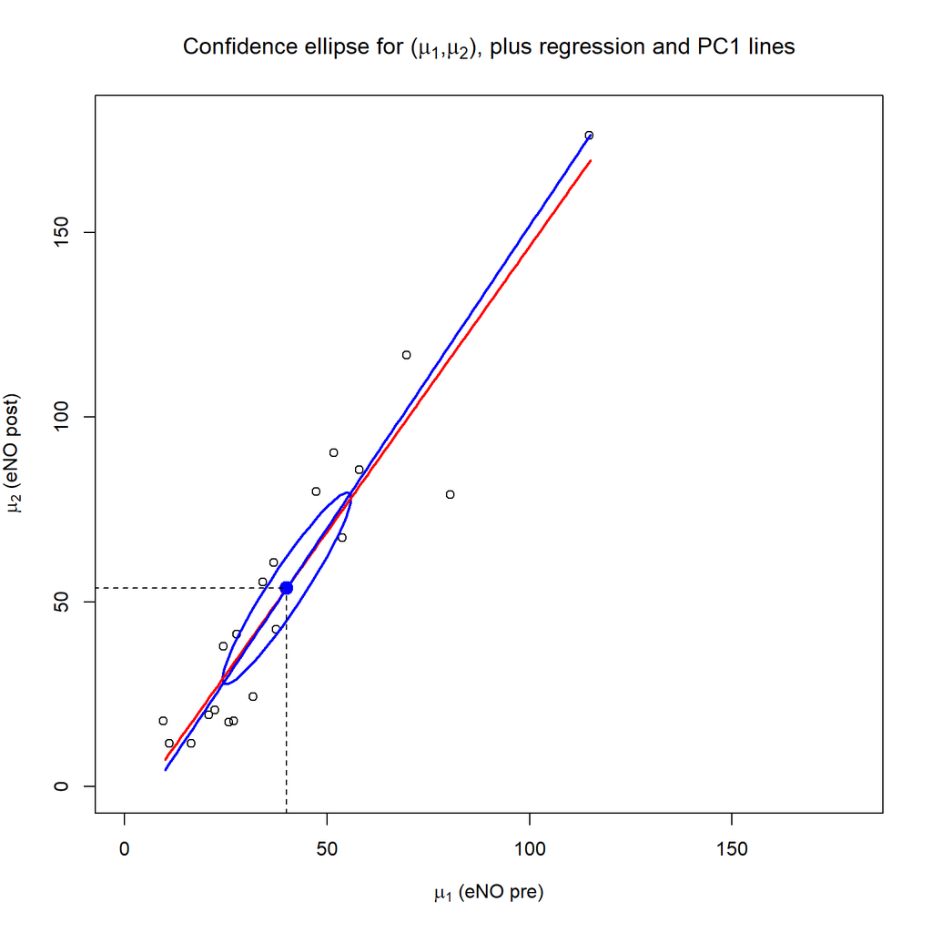

```r
eno <- here::here("data", "eno_data.txt") %>%
  read.table(header = T,  sep = " ", skip = 0)

# compute radius
N <- length(eno$eno_pre); n <- 2
f <- qf(0.95, n, N - n)
r <- sqrt((n * (N - 1) * f) / ((N - n) * N))

# covariance matrix
sigma <- mat.or.vec(2, 2)
sigma[1, 2] <- cov(eno$eno_pre, eno$eno_post); sigma[2, 1] <- sigma[1, 2]
sigma[1, 1] <- var(eno$eno_pre); sigma[2, 2] <- var(eno$eno_post)

# ellipse center (means)
mny1 <- mean(eno$eno_pre); mny2 <- mean(eno$eno_post)
# plot the data
matplot(eno$eno_pre, eno$eno_post,
  xlim = c(0, 180), ylim = c(0, 180),
  xlab = expression(mu[1] * " (eNO pre)"),
  ylab = expression(mu[2] * " (eNO post)"),
  main = expression("Confidence ellipse for (" * mu[1] * "," *  mu[2] *
                    "), plus regression and PC1 lines"), pch = 1)

# add the ellipse
ellipse(center = c(mny1, mny2), shape = sigma, radius = r)

# indicate marginal sample means
segments(40, -10, 40, 53.7, lty = 2); segments(-10, 53.7, 40, 53.7, lty = 2)

# Other Confidence ellipse info
eig <- eigen(sigma); corr <- cov2cor(sigma)

# Parts to answer the HW question
linreg <- lm(eno$eno_post ~ eno$eno_pre)
x <- c(10:115)
linregy <- -8.230 + 1.546 * x
lines(x, linregy, col = "red", lwd = 2)
slope <- sqrt(sigma[2, 2]) / sqrt(sigma[1, 1])
yint <- mean(eno$eno_post) - mean(eno$eno_pre) * (slope)
pcy <- yint + slope * x
lines(x, pcy, col = "blue", lwd = 2)
```

## Question 2. GLM, GzLM, LMM, and likelihood functions, and Variance in LMM

1. In a paragraph, explain the difference between a general linear model (GLM; not a generalized linear model, which I denote with GzLM and which will be discussed more later) and a linear mixed model (LMM).
2. In a short paragraph, explain the difference between a profiled likelihood and a restricted likelihood for a linear mixed model, and how and why they are used. Which one is a re-expression of the standard likelihood?
3. Derive $Var[\pmb {\hat \beta}]$ in a full-rank linear mixed model, given the algebraic form of $\pmb {\hat \beta}$ that is obtained via ML estimation.

   NOTE: there are two types of variance, model-based and empirical (or sandwich estimator). The difference is whether the middle $\pmb V$ is determined via the model or using squared residual quantities. To answer question c., work with the ‘complete data’ form of $\pmb {\hat \beta}$.

$$\begin{aligned}
Var(\pmb{\hat{\beta}})
&= Var((\textbf{X}^t\textbf{V}^{-1}\textbf{X})^{-1}\textbf{X}^t\textbf{V}^{-1}\textbf{Y}) &\text{ML estimate for }\pmb{\beta}\\
&= [(\textbf{X}^t\textbf{V}^{-1}\textbf{X})^{-1}\textbf{X}^t\textbf{V}^{-1}]Var(\textbf{Y})[(\textbf{X}^t\textbf{V}^{-1}\textbf{X})^{-1}\textbf{X}^t\textbf{V}^{-1}]^t &Var(\textbf{AX}) = \textbf{A}Var(\textbf{X})\textbf{A}^t \\
&= [(\textbf{X}^t\textbf{V}^{-1}\textbf{X})^{-1}\textbf{X}^t\textbf{V}^{-1}]Var(\textbf{Y})[(\textbf{V}^{-1})^t(\textbf{X}^t)^t((\textbf{X}^t\textbf{V}^{-1}\textbf{X})^{-1})^t] &(\textbf{AB})^t = \textbf{B}^t\textbf{A}^t \\
&= [(\textbf{X}^t\textbf{V}^{-1}\textbf{X})^{-1}\textbf{X}^t\textbf{V}^{-1}]Var(\textbf{Y})[\textbf{V}^{-1}\textbf{X}(\textbf{X}^t\textbf{V}^{-1}\textbf{X})^{-1}] &\textbf{A}^t=\textbf{A} \text{ symmetric} \\
&= (\textbf{X}^t\textbf{V}^{-1}\textbf{X})^{-1}(\textbf{X}^t\textbf{V}^{-1}\bcancel{\textbf{V}\textbf{V}^{-1}}\textbf{X})(\textbf{X}^t\textbf{V}^{-1}\textbf{X})^{-1} &Var(\textbf{Y}) = \textbf{V} \\
&= (\textbf{X}^t\textbf{V}^{-1}\textbf{X})^{-1}\bcancel{(\textbf{X}^t\textbf{V}^{-1}\textbf{X})}\bcancel{(\textbf{X}^t\textbf{V}^{-1}\textbf{X})^{-1}} &\textbf{A}\textbf{A}^{-1} = \textbf{I} \\
&= (\textbf{X}^t\textbf{V}^{-1}\textbf{X})^{-1}
\end{aligned}$$

## Question 3. Models for Beta Carotene data

For the Beta Carotene data (see the description of the data and the data itself in another link in the Data module). For parts **a** and **b**, model $time$ and $group$ as class variables, and include $group \times time$. In order to account for repeated measures over $time$, specify the $UN$ error covariance structure.

1. Conduct a test to compare the 30 and 60mg BASF trends over $time$ to see if they differ, i.e., an interaction test, but only involving these 2 $groups$.

```r
bc <- here::here("data", "beta_carotene_univar.csv") %>%
  read.csv() %>%
  janitor::clean_names()

ctrl <- lmc <- lmeControl(niterEM = 2000,
                          msMaxIter = 2000)

mod1 <- lme(y ~ factor(time) * factor(prepar),
            random = ~1|id,
            correlation = corSymm(form = ~1|id),
            weights = varIdent(form = ~1|time),
            control = ctrl,
            data = bc)

summary(mod1)
```

```
## Linear mixed-effects model fit by REML
##   Data: bc
##        AIC      BIC    logLik
##   1096.003 1187.943 -512.0017
##
## Random effects:
##  Formula: ~1 | id
##         (Intercept) Residual
## StdDev:    34.69523 40.26182
##
## Correlation Structure: General
##  Formula: ~1 | id
##  Parameter estimate(s):
##  Correlation:
##   1     2     3     4
## 2 0.635
## 3 0.889 0.915
## 4 0.673 0.905 0.901
## 5 0.723 0.914 0.915 0.940
## Variance function:
##  Structure: Different standard deviations per stratum
##  Formula: ~1 | time
##  Parameter estimates:
##        0        6        8       10       12
## 1.000000 2.827353 2.865491 2.507458 2.645924
## Fixed effects:  y ~ factor(time) * factor(prepar)
##                                    Value Std.Error DF   t-value p-value
## (Intercept)                    148.33333  21.69782 76  6.836324  0.0000
## factor(time)6                   92.33333  38.20699 76  2.416661  0.0181
## factor(time)8                   99.33333  33.34540 76  2.978922  0.0039
## factor(time)10                 127.00000  32.51108 76  3.906360  0.0002
## factor(time)12                 124.33333  33.58622 76  3.701915  0.0004
## factor(prepar)2                -28.00000  30.68535 19 -0.912487  0.3729
## factor(prepar)3                 14.86667  32.18307 19  0.461941  0.6494
## factor(prepar)4                  7.33333  30.68535 19  0.238985  0.8137
## factor(time)6:factor(prepar)2  -10.00000  54.03284 76 -0.185073  0.8537
## factor(time)8:factor(prepar)2  -10.33333  47.15752 76 -0.219124  0.8271
## factor(time)10:factor(prepar)2 -68.33333  45.97762 76 -1.486230  0.1414
## factor(time)12:factor(prepar)2 -58.00000  47.49809 76 -1.221102  0.2258
## factor(time)6:factor(prepar)3   59.26667  56.67012 76  1.045819  0.2990
```

[output cut: 80 more lines]

```
## factor(time)6:factor(prepar)3
## factor(time)8:factor(prepar)3
## factor(time)10:factor(prepar)3
## factor(time)12:factor(prepar)3
## factor(time)6:factor(prepar)4
## factor(time)8:factor(prepar)4
## factor(time)10:factor(prepar)4  0.807
## factor(time)12:factor(prepar)4  0.839    0.900
##
## Standardized Within-Group Residuals:
##        Min         Q1        Med         Q3        Max
## -1.8136290 -0.6258979 -0.1143104  0.4922215  2.4353170
##
## Number of Observations: 115
## Number of Groups: 23
```

```r
# model_parameters(mod1)
# model_parameters(mod1, df_method = "satterthwaite")
```

```r
## sidenotes of pulling results from lme objects

## random effect G matrix
G <- getVarCov(mod1); G[1]
```

```
## [1] 1203.759
```

```r
## random effect R matrix
R <- getVarCov(mod1, type = "conditional", digit = 2); R$`71`
```

```
##          1         2         3         4         5
## 1 1621.014  2910.319  4129.865  2735.533  3100.692
## 2 2910.319 12958.267 12011.343 10395.877 11083.734
## 3 4129.865 12011.343 13310.210 10493.432 11246.429
## 4 2735.533 10395.877 10493.432 10191.875 10109.338
## 5 3100.692 11083.734 11246.429 10109.338 11348.577
```

```r
r <- round(R$`71`, 2) %>% cov2cor(); r ## R correlation matrix
```

```
##           1         2         3         4         5
## 1 1.0000000 0.6350010 0.8890988 0.6730099 0.7229275
## 2 0.6350010 1.0000000 0.9145880 0.9046084 0.9139905
## 3 0.8890988 0.9145880 1.0000000 0.9009441 0.9150640
## 4 0.6730099 0.9046084 0.9009441 1.0000000 0.9399936
## 5 0.7229275 0.9139905 0.9150640 0.9399936 1.0000000
```

```r
## random effect V matrix
V <- getVarCov(mod1, type = "marginal"); V$`71`
```

```
##          1         2         3         4         5
## 1 2824.773  4114.078  5333.624  3939.292  4304.451
## 2 4114.078 14162.026 13215.101 11599.635 12287.493
## 3 5333.624 13215.101 14513.969 11697.191 12450.187
## 4 3939.292 11599.635 11697.191 11395.634 11313.096
## 5 4304.451 12287.493 12450.187 11313.096 12552.336
```

```r
## sigma_r^2 and sigma_b^2
S <- VarCorr(mod1); S
```

```
## id = pdLogChol(1)
##             Variance StdDev
## (Intercept) 1203.759 34.69523
## Residual    1621.014 40.26182
```

```r
## random effect eBLUP
rand_ef <- ranef(mod1); rand_ef
```

|  | (Intercept) |
| --- | --- |
| 71 | -14.586247 |
| 72 | 14.665318 |
| 73 | -11.019127 |
| 74 | 19.202334 |
| 75 | 2.899746 |
| 76 | 30.051363 |
| 77 | 28.427917 |
| 78 | 10.500175 |
| 79 | 23.919916 |
| 80 | 51.521305 |

[output cut: 13 more lines]

```r
## fixed effects
beta_hat <- fixed.effects(mod1); beta_hat
```

```
##                    (Intercept)                  factor(time)6
##                     148.333333                      92.333333
##                  factor(time)8                 factor(time)10
##                      99.333333                     127.000000
##                 factor(time)12                factor(prepar)2
##                     124.333333                     -28.000000
##                factor(prepar)3                factor(prepar)4
##                      14.866667                       7.333333
##  factor(time)6:factor(prepar)2  factor(time)8:factor(prepar)2
##                     -10.000000                     -10.333333
## factor(time)10:factor(prepar)2 factor(time)12:factor(prepar)2
##                     -68.333333                     -58.000000
##  factor(time)6:factor(prepar)3  factor(time)8:factor(prepar)3
##                      59.266667                      17.466667
## factor(time)10:factor(prepar)3 factor(time)12:factor(prepar)3
##                      34.200000                      72.466667
##  factor(time)6:factor(prepar)4  factor(time)8:factor(prepar)4
##                      77.333333                      69.333333
## factor(time)10:factor(prepar)4 factor(time)12:factor(prepar)4
##                      12.000000                      23.666667
```

```r
C <- vcov(mod1); C
```

```
##                                (Intercept) factor(time)6 factor(time)8
## (Intercept)                       470.7955      214.8842      418.1418
## factor(time)6                     214.8842     1459.7737     1098.6954
## factor(time)8                     418.1418     1098.6954     1111.9158
## factor(time)10                    185.7531     1061.8397      874.8414
## factor(time)12                    246.6130     1115.6227      939.4809
## factor(prepar)2                  -470.7955     -214.8842     -418.1418
## factor(prepar)3                  -470.7955     -214.8842     -418.1418
## factor(prepar)4                  -470.7955     -214.8842     -418.1418
## factor(time)6:factor(prepar)2    -214.8842    -1459.7737    -1098.6954
## factor(time)8:factor(prepar)2    -418.1418    -1098.6954    -1111.9158
## factor(time)10:factor(prepar)2   -185.7531    -1061.8397     -874.8414
## factor(time)12:factor(prepar)2   -246.6130    -1115.6227     -939.4809
## factor(time)6:factor(prepar)3    -214.8842    -1459.7737    -1098.6954
## factor(time)8:factor(prepar)3    -418.1418    -1098.6954    -1111.9158
## factor(time)10:factor(prepar)3   -185.7531    -1061.8397     -874.8414
## factor(time)12:factor(prepar)3   -246.6130    -1115.6227     -939.4809
## factor(time)6:factor(prepar)4    -214.8842    -1459.7737    -1098.6954
## factor(time)8:factor(prepar)4    -418.1418    -1098.6954    -1111.9158
## factor(time)10:factor(prepar)4   -185.7531    -1061.8397     -874.8414
## factor(time)12:factor(prepar)4   -246.6130    -1115.6227     -939.4809
##                                factor(time)10 factor(time)12 factor(prepar)2
## (Intercept)                          185.7531       246.6130       -470.7955
## factor(time)6                       1061.8397      1115.6227       -214.8842
## factor(time)8                        874.8414       939.4809       -418.1418
## factor(time)10                      1056.9706       982.3544       -185.7531
## factor(time)12                       982.3544      1128.0344       -246.6130
## factor(prepar)2                     -185.7531      -246.6130        941.5910
## factor(prepar)3                     -185.7531      -246.6130        470.7955
## factor(prepar)4                     -185.7531      -246.6130        470.7955
## factor(time)6:factor(prepar)2      -1061.8397     -1115.6227        429.7685
## factor(time)8:factor(prepar)2       -874.8414      -939.4809        836.2836
## factor(time)10:factor(prepar)2     -1056.9706      -982.3544        371.5063
## factor(time)12:factor(prepar)2      -982.3544     -1128.0344        493.2260
## factor(time)6:factor(prepar)3      -1061.8397     -1115.6227        214.8842
## factor(time)8:factor(prepar)3       -874.8414      -939.4809        418.1418
## factor(time)10:factor(prepar)3     -1056.9706      -982.3544        185.7531
## factor(time)12:factor(prepar)3      -982.3544     -1128.0344        246.6130
## factor(time)6:factor(prepar)4      -1061.8397     -1115.6227        214.8842
## factor(time)8:factor(prepar)4       -874.8414      -939.4809        418.1418
```

[output cut: 260 more lines]

```
## factor(prepar)2                                      246.6130
## factor(prepar)3                                      246.6130
## factor(prepar)4                                      493.2260
## factor(time)6:factor(prepar)2                       1115.6227
## factor(time)8:factor(prepar)2                        939.4809
## factor(time)10:factor(prepar)2                       982.3544
## factor(time)12:factor(prepar)2                      1128.0344
## factor(time)6:factor(prepar)3                       1115.6227
## factor(time)8:factor(prepar)3                        939.4809
## factor(time)10:factor(prepar)3                       982.3544
## factor(time)12:factor(prepar)3                      1128.0344
## factor(time)6:factor(prepar)4                       2231.2453
## factor(time)8:factor(prepar)4                       1878.9619
## factor(time)10:factor(prepar)4                      1964.7089
## factor(time)12:factor(prepar)4                      2256.0689
```

```r
##             [1]  [2] [3] [4]  [5]  [6] [7] [8] [9]   [10]  [11]   [12]   [13]  [14]  [15]   [16]   [17]  [18]  [19]   [20]
## coefs       Int  t6  t8  t10  t12  p2  p3  p4  t6:p2 t8:p2 t10:p2 t12:p2 t6:p3 t8:p3 t10:p3 t12:p3 t6:p4 t8:p4 t10:p4 t12:p4
p3_p4_t0 <- c( 0,   0,  0,  0,   0,   0,  1,  -1,  0,    0,   0,     0,     0,    0,    0,     0,     0,    0,    0,     0)
## p3_t6 <- c( 0,   1,  0,  0,   0,   0,  1,  0,   0,    0,   0,     0,     1,    0,    0,     0,     0,    0,    0,     0)
## p4_t6 <- c( 0,   1,  0,  0,   0,   0,  0,  1,   0,    0,   0,     0,     0,    0,    0,     0,     1,    0,    0,     0)
## p3_p4_t6 <- p3_t6 - p4_t6, similarly for other time points
p3_p4_t6 <- c( 0,   0,  0,  0,   0,   0,  1,  -1,  0,    0,   0,     0,     1,    0,    0,     0,     -1,    0,    0,    0)
p3_p4_t8 <- c( 0,   0,  0,  0,   0,   0,  1,  -1,  0,    0,   0,     0,     0,    1,    0,     0,     0,    -1,    0,    0)
p3_p4_t10 <- c(0,   0,  0,  0,   0,   0,  1,  -1,  0,    0,   0,     0,     0,    0,    1,     0,     0,     0,   -1,    0)
p3_p4_t12 <- c(0,   0,  0,  0,   0,   0,  1,  -1,  0,    0,   0,     0,     0,    0,    0,     1,     0,     0,    0,   -1)
contr1 <- cbind(p3_p4_t0, p3_p4_t6, p3_p4_t8, p3_p4_t10, p3_p4_t12)
rownames(contr1) <- rownames(C)
```

```r
## View design matrix
# X <- model.matrix(mod1, data = bc) %>% as.matrix()
# View(X)
ctb <- t(contr1) %*% beta_hat; ctb
```

```
##                 [,1]
## p3_p4_t0    7.533333
## p3_p4_t6  -10.533333
## p3_p4_t8  -44.333333
## p3_p4_t10  29.733333
## p3_p4_t12  56.333333
```

```r
covtb <- t(contr1) %*% C %*% contr1
sdtb <- sqrt(diag(covtb)); sdtb
```

```
##  p3_p4_t0  p3_p4_t6  p3_p4_t8 p3_p4_t10 p3_p4_t12
##  32.18307  72.06069  72.95059  64.64054  67.84190
```

```r
emm1 <- emmeans(## the first arg is the object
                mod1,
                ## specs arg is in formula status
                specs = pairwise ~ time:prepar,
                at = list(time = c(0, 6, 8, 10, 12),
                          prepar = c(3, 4)),
                sigmaAdjust = TRUE)

emm1$contrasts %>% as.data.frame() %>%
  filter(contrast %in% c("0 3 - 0 4",
                         "6 3 - 6 4",
                         "8 3 - 8 4",
                         "10 3 - 10 4",
                         "12 3 - 12 4"))
```

| contrast | estimate | SE | df | t.ratio | p.value |
| --- | --- | --- | --- | --- | --- |
| 0 3 - 0 4 | 7.533333 | 32.18307 | 19 | 0.2340775 | 0.9999999 |
| 6 3 - 6 4 | -10.533333 | 72.06069 | 19 | -0.1461731 | 1.0000000 |
| 8 3 - 8 4 | -44.333333 | 72.95059 | 19 | -0.6077173 | 0.9997317 |
| 10 3 - 10 4 | 29.733333 | 64.64054 | 19 | 0.4599797 | 0.9999733 |
| 12 3 - 12 4 | 56.333333 | 67.84190 | 19 | 0.8303620 | 0.9969687 |

```r
# emm1$emmeans
```

2. Conduct a test to compare to see if the 12 week - baseline value differs between the 4 $groups$.

```r
emm2 <- emmeans(## the first arg is the object
                mod1,
                ## specs arg is in formula status
                specs = pairwise ~ time:prepar,
                at = list(time = c(0, 12)))
emm2$contrasts %>% as.data.frame() %>%
  filter(contrast %in% c("0 1 - 12 1",
                         "0 2 - 12 2",
                         "0 3 - 12 3",
                         "0 4 - 12 4"))
```

| contrast | estimate | SE | df | t.ratio | p.value |
| --- | --- | --- | --- | --- | --- |
| 0 1 - 12 1 | -124.33333 | 33.58622 | 76 | -3.701915 | 0.0091520437 |
| 0 2 - 12 2 | -66.33333 | 33.58622 | 76 | -1.975016 | 0.5052344994 |
| 0 3 - 12 3 | -196.80000 | 36.79186 | 76 | -5.349009 | 0.0000241509 |
| 0 4 - 12 4 | -148.00000 | 33.58622 | 76 | -4.406569 | 0.0008555380 |

```r
# emm2$emmeans
```

3. Consider the model that uses $time$ as continuous, with up to cubic effects, plus interactions between group and time (up to cubic). How does this model compare with the one that uses $time$ as class (plus interactions)? Discuss in a paragraph.

```r
mod2 <- lme(y ~ time * factor(prepar) +
              I(time^2) * factor(prepar) +
              I(time^3) * factor(prepar),
            random = ~1|id,
            correlation = corSymm(form = ~1|id),
            weights = varIdent(form = ~1|time),
            control = ctrl,
            data = bc)

summary(mod2)
```

```
## Linear mixed-effects model fit by REML
##   Data: bc
##        AIC      BIC    logLik
##   1208.053 1291.096 -572.0263
##
## Random effects:
##  Formula: ~1 | id
##         (Intercept) Residual
## StdDev:    34.62265 40.98863
##
## Correlation Structure: General
##  Formula: ~1 | id
##  Parameter estimate(s):
##  Correlation:
##   1     2     3     4
## 2 0.628
## 3 0.888 0.912
## 4 0.662 0.904 0.897
## 5 0.718 0.914 0.914 0.939
## Variance function:
##  Structure: Different standard deviations per stratum
##  Formula: ~1 | time
##  Parameter estimates:
##        0        6        8       10       12
## 1.000000 2.778397 2.829405 2.463599 2.601792
## Fixed effects:  y ~ time * factor(prepar) + I(time^2) * factor(prepar) + I(time^3) *      factor(prepar)
##                               Value Std.Error DF   t-value p-value
## (Intercept)               158.32309  18.02628 80  8.782903  0.0000
## time                       16.08273  22.51731 80  0.714239  0.4772
## factor(prepar)2           -50.87352  25.49301 19 -1.995587  0.0605
## factor(prepar)3            27.69661  26.73730 19  1.035879  0.3133
## factor(prepar)4           -12.18351  25.49301 19 -0.477916  0.6382
## I(time^2)                  -0.09451   4.05546 80 -0.023304  0.9815
## I(time^3)                  -0.03417   0.19797 80 -0.172608  0.8634
## time:factor(prepar)2       25.26154  31.84428 80  0.793284  0.4300
## time:factor(prepar)3       50.90026  33.39857 80  1.524025  0.1314
## time:factor(prepar)4       60.31572  31.84428 80  1.894083  0.0618
## factor(prepar)2:I(time^2)  -5.68959   5.73529 80 -0.992033  0.3242
## factor(prepar)3:I(time^2) -10.37242   6.01522 80 -1.724363  0.0885
## factor(prepar)4:I(time^2) -10.28267   5.73529 80 -1.792878  0.0768
```

[output cut: 44 more lines]

```
## time:factor(prepar)3
## time:factor(prepar)4
## factor(prepar)2:I(time^2)
## factor(prepar)3:I(time^2)
## factor(prepar)4:I(time^2)
## factor(prepar)2:I(time^3)
## factor(prepar)3:I(time^3)  0.477
## factor(prepar)4:I(time^3)  0.500     0.477
##
## Standardized Within-Group Residuals:
##        Min         Q1        Med         Q3        Max
## -1.8101635 -0.6866712 -0.1999811  0.4920711  2.4864125
##
## Number of Observations: 115
## Number of Groups: 23
```

```r
# fixef(mod2) %>% length
# fixef(mod1) %>% length
AIC(mod1, mod2)
```

|  | df | AIC |
| --- | --- | --- |
| mod1 | 36 | 1096.003 |
| mod2 | 32 | 1208.053 |

4. Modeling the data using $Time 0$ as a covariate value, with the remaining $times$ as repeated measures on the outcome (6, 8, 10, 12 weeks). What are pros and cons of this approach, relative to using all measures as outcome values in a longitudinal model? In particular, focuses on the modeling of the repeated measures, how fixed effects need to be specified, and impact of modeling of $time$ as class versus continuous.
5. For the model in part **d**, estimate the linear, quadratic and cubic trends for the model that uses $time$ as a class variable.

## Question 4. Constrasts

Consider a study where $subjects$ in 3 $groups$ (e.g., race or treatment) are observed over 3 equally spaced $times$ and some health outcome, $y$, is measured. Unless otherwise mentioned, include a random intercept for subjects to account for the repeated measures. For simplicity, use 2 $subjects$ per $group$.

1. Consider modeling $group$ and $time$ as class variables, plus interaction. Write statistical models and the $\pmb X$ matrix for the following cases.
   1. No restriction placed on the model. i.e., write the less-than-full-rank statistical model.

$$\begin{split}
& Y_{grp = g, sub = i, time = t} = \beta_{pop} + \alpha_{g} + \tau_{t} + \gamma_{g\times t} + b_{i} + \epsilon_{g, i, t}\\
& b_i \stackrel {iid} \sim \mathcal N(0, \sigma^2_b)\\
& \epsilon_i \stackrel {iid} \sim \mathcal N(0, \sigma^2_\epsilon)\\
\end{split}$$

```r
group <- rep(c("A", "B", "C"), each = 6)
time <- rep(c("1", "2", "3"))
id <- rep(1:6, each = 3)
y <- "NA"
data_s <- cbind(id, group, time, y) %>%
  as.data.frame()

form1 <- formula(y ~ 1 +
                   I(group == "A") + I(group == "B") + I(group == "C") +
                   I(time == "1") + I(time == "2") + I(time == "t3") +
                   group:time)
mod_f1 <- model.frame(form1, # Formula
                      # Data frame
                      data = data_s,
                      # Identifier of data records
                      SubjectId = id)
Xmtx1 <- model.matrix(form1,
                       mod_f1)
# colnames(Xmtx1) <- NULL
Xmtx1
```

```
##    (Intercept) I(group == "A")TRUE I(group == "B")TRUE I(group == "C")TRUE
## 1            1                   1                   0                   0
## 2            1                   1                   0                   0
## 3            1                   1                   0                   0
## 4            1                   1                   0                   0
## 5            1                   1                   0                   0
## 6            1                   1                   0                   0
## 7            1                   0                   1                   0
## 8            1                   0                   1                   0
## 9            1                   0                   1                   0
## 10           1                   0                   1                   0
## 11           1                   0                   1                   0
## 12           1                   0                   1                   0
## 13           1                   0                   0                   1
## 14           1                   0                   0                   1
```

[output cut: 87 more lines]

```
ii. A set-to-0 restriction is placed on the parameters associated with highest levels.
```

$$Y_{grp = g, sub = i, time = t} = \beta_{0} + \beta_{gA}x_{1i} + \beta_{gB}x_{2i} + \beta_{t1}x_{3} +
\beta_{t2}x_{4} + \beta_{g1:t1}x_{1i}x_3 + \beta_{g1:t2}x_{1i}x_4 + \beta_{g2:t1}x_{2i}x_3 +\beta_{g2:t2}x_{2i}x_4 + \epsilon_{g, i, t}$$

```r
form2 <- formula(y ~ 1 + group + time + group:time)
mod_f2 <- model.frame(form2, # Formula
                      # Data frame
                      data = data_s,
                      # Identifier of data records
                      SubjectId = id)
Xmtx2 <- model.matrix(form2,
                      mod_f2,
                      contrasts.arg = list(group = "contr.SAS",
                                           time = "contr.SAS"))
# colnames(Xmtx2) <- NULL
Xmtx2
```

```
##    (Intercept) groupA groupB time1 time2 groupA:time1 groupB:time1 groupA:time2
## 1            1      1      0     1     0            1            0            0
## 2            1      1      0     0     1            0            0            1
## 3            1      1      0     0     0            0            0            0
## 4            1      1      0     1     0            1            0            0
## 5            1      1      0     0     1            0            0            1
## 6            1      1      0     0     0            0            0            0
## 7            1      0      1     1     0            0            1            0
## 8            1      0      1     0     1            0            0            0
## 9            1      0      1     0     0            0            0            0
## 10           1      0      1     1     0            0            1            0
## 11           1      0      1     0     1            0            0            0
## 12           1      0      1     0     0            0            0            0
## 13           1      0      0     1     0            0            0            0
## 14           1      0      0     0     1            0            0            0
```

[output cut: 31 more lines]

2. Show that the linear trend for one $group$ compared to another (say $Group A$ versus $Group B$) is estimable by showing that $\pmb L = \pmb {LH}$, where the Moore-Penrose inverse is used in calculating $\pmb H$. First you need to construct $\pmb L$. (As a check, you can repeat using SAS’s g-inverse in calculating $\pmb H$, but you don’t need to turn that in.)

```r
##     [1]   [2]  [3]   [4]   [5]  [6]  [7]   [8]  [9]  [10]  [11]  [12]  [13]  [14]  [15]  [16]
L1 <- c(0,    0,   0,    0,    0,   0,   0,   -1,   0,   1,    1,    0,   -1,    0,    0,    0)
XtX1 <- t(Xmtx1) %*% Xmtx1
H1 <- MASS::ginv(XtX1) %*% XtX1
round(L1 %*% H1)
```

```
##      (Intercept) I(group == "A")TRUE I(group == "B")TRUE I(group == "C")TRUE
## [1,]           0                   0                   0                   0
##      I(time == "1")TRUE I(time == "2")TRUE I(time == "t3")TRUE groupA:time1
## [1,]                  0                  0                   0           -1
##      groupB:time1 groupC:time1 groupA:time2 groupB:time2 groupC:time2
## [1,]            0            1            1            0           -1
##      groupA:time3 groupB:time3 groupC:time3
## [1,]            0            0            0
```

```r
##     [1]   [2]  [3]   [4]   [5]  [6]  [7]   [8]  [9]
L2 <- c(1,    0,   -1,    0,    1,   0,   0,   -1,   0)
XtX2 <- t(Xmtx2) %*% Xmtx2
H2 <- solve(XtX2) %*% XtX2
round(L2 %*% H2)
```

```
##      (Intercept) groupA groupB time1 time2 groupA:time1 groupB:time1
## [1,]           1      0     -1     0     1            0            0
##      groupA:time2 groupB:time2
## [1,]           -1            0
```

3. How would answers in a change in part **a** if an AR(1) structure for $\pmb R$ is included? (You do not need to rewrite entire models, just mention what changes).
4. Say that $Time$ is treated as continuous (i.e., not included in the CLASS statement in SAS or factor argument in R). Rewrite either the full-rank or less-than-full-rank model (clearly specify which one) and $\pmb X$ matrices in **a**. Say the linear term for $Time$ is sufficient.

```r
form3 <- formula(y ~ 1 + group + as.integer(time) + group:as.integer(time))
mod_f3 <- model.frame(form3, # Formula
                      # Data frame
                      data = data_s,
                      # Identifier of data records
                      SubjectId = id)
Xmtx3 <- model.matrix(form3,
                      mod_f3,
                      contrasts.arg = list(group = "contr.SAS"))
Xmtx3
```

```
##    (Intercept) groupA groupB as.integer(time) groupA:as.integer(time)
## 1            1      1      0                1                       1
## 2            1      1      0                2                       2
## 3            1      1      0                3                       3
## 4            1      1      0                1                       1
## 5            1      1      0                2                       2
## 6            1      1      0                3                       3
## 7            1      0      1                1                       0
## 8            1      0      1                2                       0
## 9            1      0      1                3                       0
## 10           1      0      1                1                       0
## 11           1      0      1                2                       0
## 12           1      0      1                3                       0
## 13           1      0      0                1                       0
## 14           1      0      0                2                       0
```

[output cut: 28 more lines]

5. Say that the times of observation were at 0, 1 and 6 months rather than equally spaced.
   1. Would it be appropriate to treat $Time$ as a class variable in this case? Explain.

```
ii. Suggest a structure for $\pmb R_1$ and write it out.
```

So in `R`, the SAS UN structure in fact is a Symmetric correlation matrix (with 3 parameters) and a variance vector (with 3 parameter, more precisely one variance, and two correlation parameters)